# Biogeography: Diversifying in New Spaces

Macroevolution · PB 495/595 Plant Evolutionary Biology

George P. Tiley

10 November 2026

# Biogeography

## Summary

- Basic concept: species richness = rate × time
- A clade might be diverse because it is old or diversifies fast.
- Those rates might be associated with a trait
- Geography or environment can be associated with rates too:
  1. Why do some regions hold far more species than others?
  2. How have diversification rates changed through time?
  3. What are the geographic origins of lineages and how have they moved around?

## Learning objectives

By the end you should be able to:

- Describe how plant richness and endemism vary among regions
- Explain the difference between **cradles** and **museums**
- Explain how different histories of rate variation through time can produce the same tree shape.
- Describe DEC as an extension of the Mk model to geographic ranges
- Recognize the limits of biogeographic inference

# Diversity is uneven in space

## Where are species?

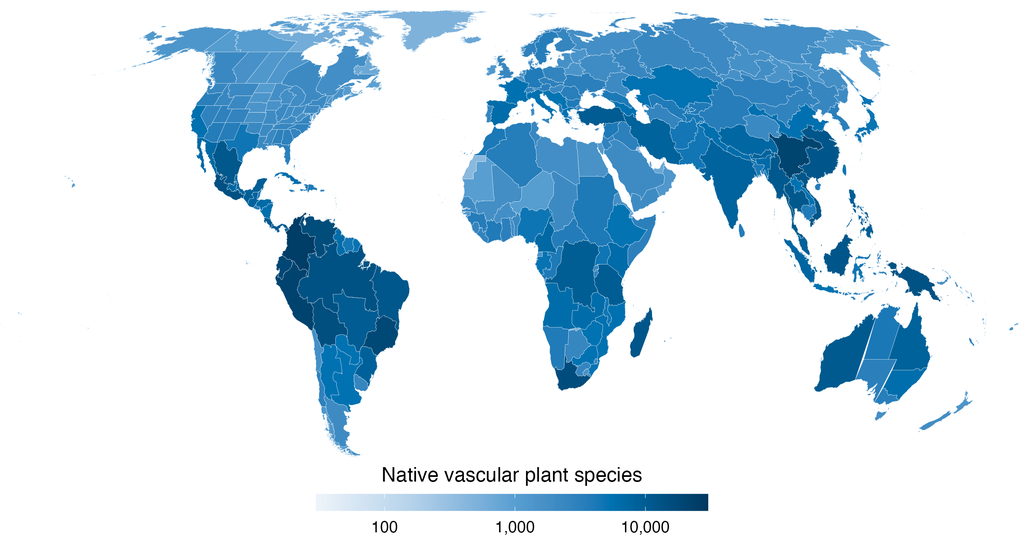

Colombia has 25,407 native species. Greenland has 502. Data from the World Checklist of Vascular Plants Govaerts et al. (2021) based on accepted species excluding hybrids. Equal Earth projection.

## More species toward the equator

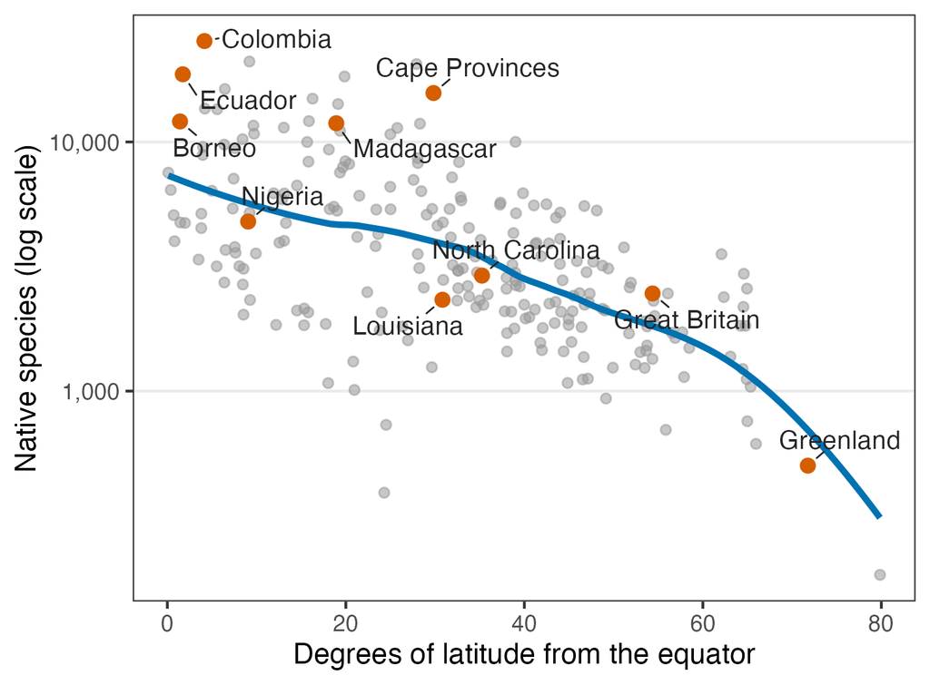

Number of native species per Level-III Botanical Region of at least 50,000 $km^2$

- Each $10^\circ$ from the equator is about 25% less species.
- One of the oldest observations from Natural History, the causes debated from Darwin and Wallace to Stebbins to today (Mittelbach et al. 2007).

## Endemism: islands and Mediterranean climates

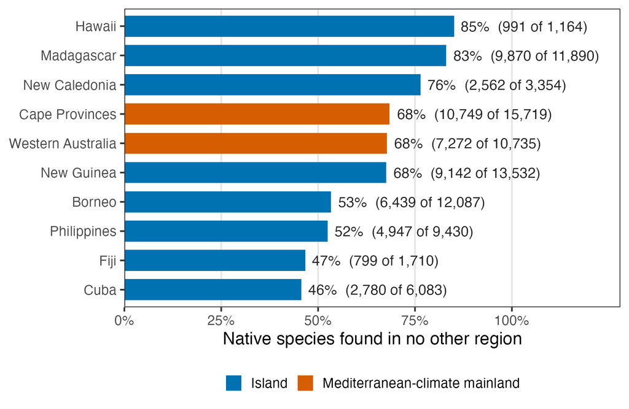

Highest proportions of endemic species are found on island (botanical regions) and Mediterranean-climate (Köppen Cs) mainland regions.

- endemics are native to only one region.
- Hawaii is #1 - recall the silverswords (1 October) will return.

## Richness = rate × time, in space

Thought experiment: a family has 400 species in the tropics and 120 in a temperate region. What are three possible explanations?

## Richness = rate × time, in space

Thought experiment: a family has 400 species in the tropics and 120 in a temperate region. What are three possible explanations?

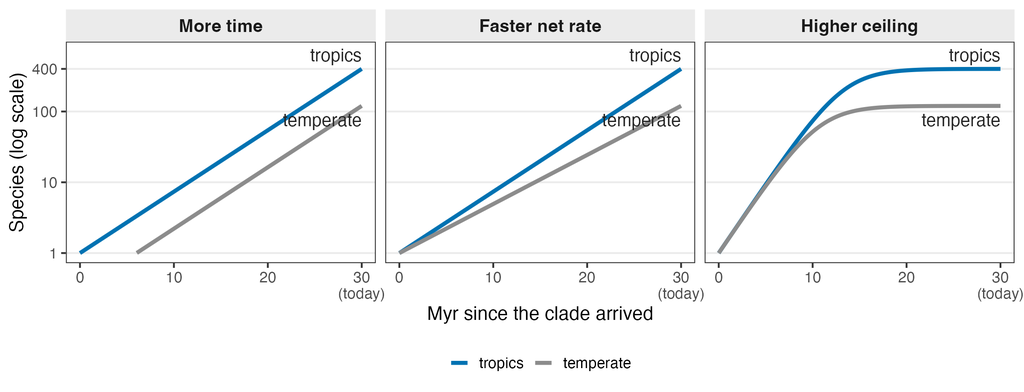

More time: $r_{trop} = r_{temp} = 0.2$, Faster rate: $r_{trop} = 0.2$ and $r_{temp} = 0.16$, Higher ceiling: Logistic growth with $K_{trop} = 400$ and $K_{temp} = 120$ with both starting at $r = 0.45$.

Goal: differentiate these scenarios based on present-day counts.

## Cradles and museums

- **Cradle:** the tropics make species faster (higher $\lambda$).
- **Museum:** tropical species last longer (lower $\mu$) (Jablonski, Roy, and Valentine 2006; Mittelbach et al. 2007).

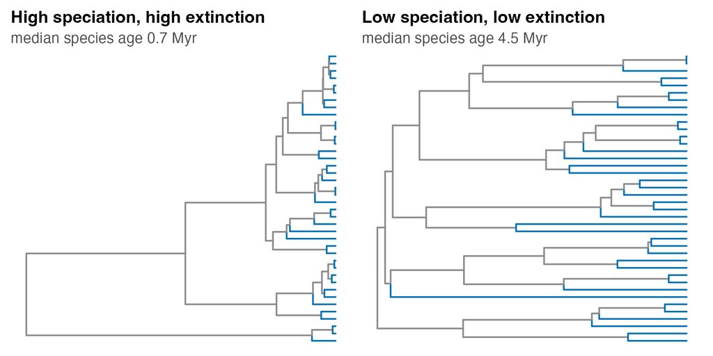

Trees simulated with a crown age of 30 Myr and retaining 40 tips.

Already established that differentiating combinations of $\lambda$ and $\mu$ is challenging if not impossible. Probably both processes contribute to the observed patterns.

## Why a museum? The past was very tropical!

The case for the **tropical niche conservatism (TNC) hypothesis**

- Angiosperms likely diversified through warm, wet climates, and tropical biomes were larger for most of their history.
- Lineages keep their climate tolerances, and few evolved ways to survive freezing (Wiens and Donoghue 2004).
- About 12,500 woody species in the temperate Americas come from a few clades that are young and shared ancestors with tropical clades (Kerkhoff, Moriarty, and Weiser 2014).
- Most temperate lineages arose after global cooling began. The Oligocene, 34 million years ago.

## Why a museum? The past was very tropical!

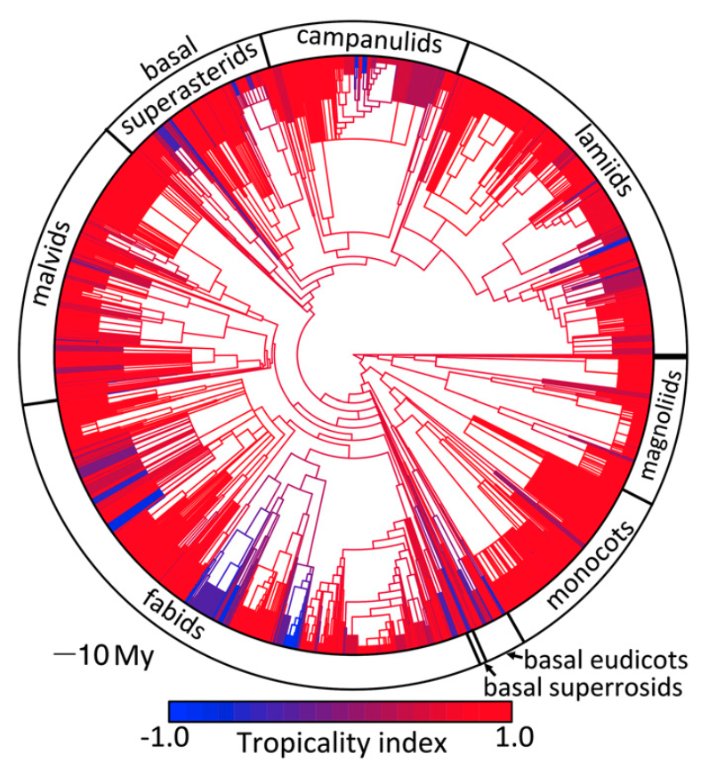

Oligocene origins of temperate woody plants. Fig. 3 from Kerkhoff, Moriarty, and Weiser (2014)

## Why a museum? The past was very tropical!

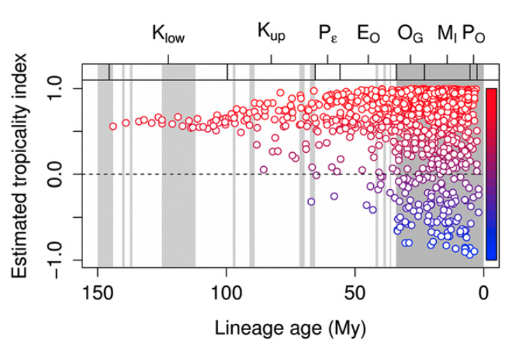

Oligocene origins of temperate woody plants. Fig. 5 from Kerkhoff, Moriarty, and Weiser (2014)

## Do tropical plants diversify faster?

Across seed plants: diversification rate and richness are unrelated. Rates peak in dry regions with varied soils that experienced variable climates since the Oligocene (Tietje et al. 2022).

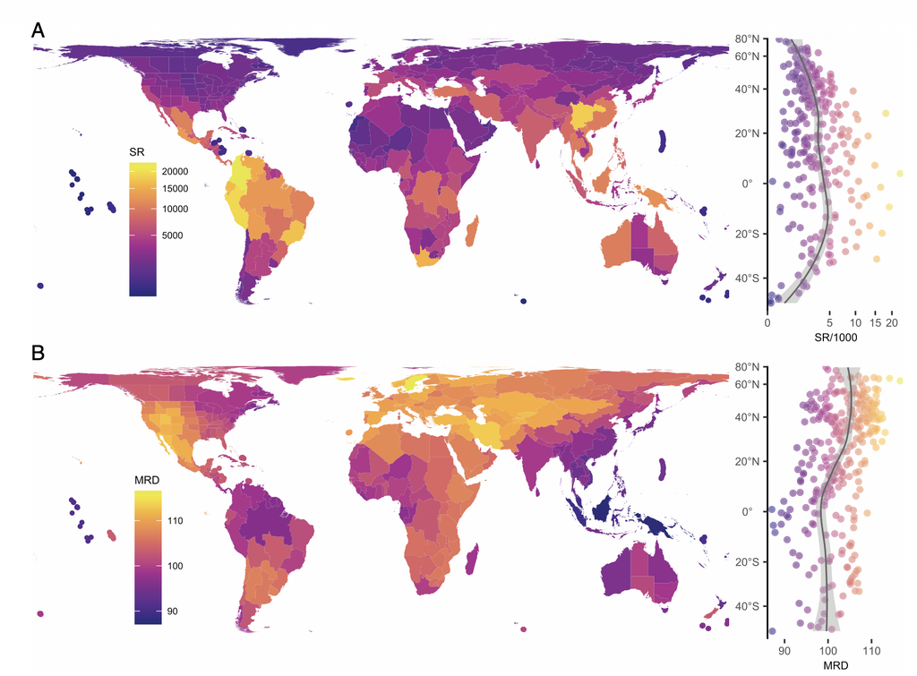

Decoupling of species richness and diversification rate. Fig. 1 from Tietje et al. (2022)

## Do tropical plants diversify faster?

Most research favors that time, more time for species accumulation with a higher carrying capacity, rather than faster diversification rates, explains the higher richness in the tropics.

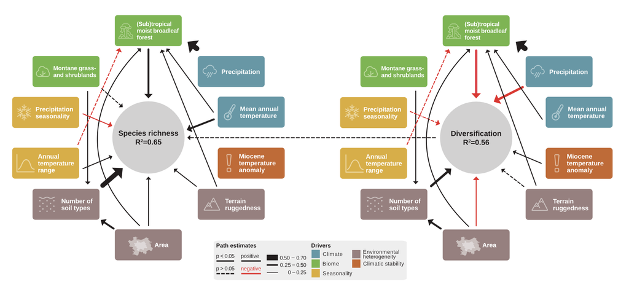

Highest predictor of both processes, variable soil. Fig. 2 from Tietje et al. (2022)

## Connections to microevolution

Likely covaring aspects of the tropics that lead to isolation and speciation.

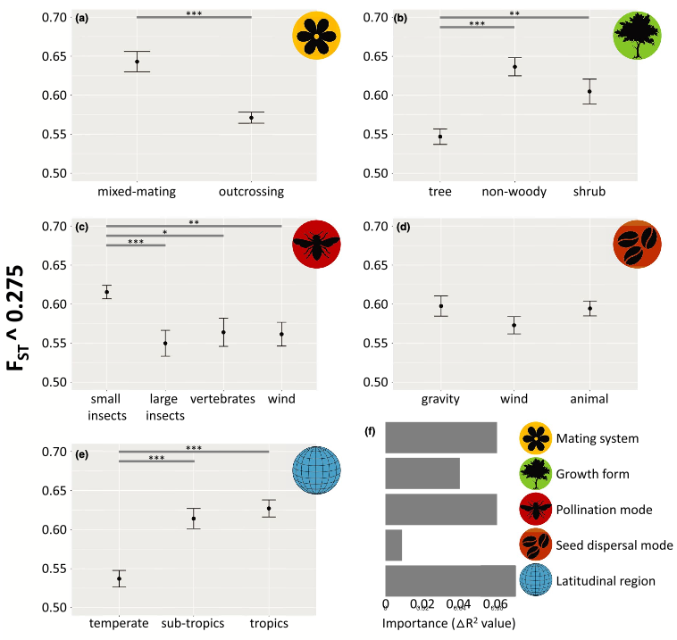

Marginal effects of features on $F_{ST}$ across plants from Gamba and Muchhala (2020)

# Rates change through time

## From constant rates to $\lambda(t)$

So far, we have assumed that the speciation and extinction rates are constant through time. We allowed rates to vary between states with BiSSE, but the rate would be the same for a state 0 at 1 Myr versus 150 Myr.

What are some reasons the rates might change through time?

- Environmental changes (climate shifts, habitat availability)
- **Key innovations** (Traits that open new niches)
- Mass extinction events
- Diversity-dependent processes (speciation slows as niches fill)

## From constant rates to $\lambda(t)$

Let $\lambda$ and $\mu$ change with time $t$ before the present. The equations keep the same form:

$$\begin{aligned}
\frac{dD}{dt} &= \bbox[#DCEBFA,3px]{-\big(\lambda(t) + \mu(t)\big)\,D} + \bbox[#FBE3E3,3px]{2\lambda(t)\,E\,D} \\[10pt]
\frac{dE}{dt} &= \mu(t) - \big(\lambda(t) + \mu(t)\big)\,E + \lambda(t)\,E^2
\end{aligned}$$

- $\bbox[#DCEBFA,3px]{\text{Blue}}$: nothing happens. $\bbox[#FBE3E3,3px]{\text{Red}}$: a split with one side lost. We have one state, so no state changes here.
- Tips start from $E(0) = 1 - f$ as before, and each node contributes $\lambda(t_{\text{node}})$.
- The rates can be functions of time (linear, exponential) or constant within time intervals (Morlon, Parsons, and Plotkin 2011; Stadler 2011).

## How do rate changes affect lineage-through-time curves?

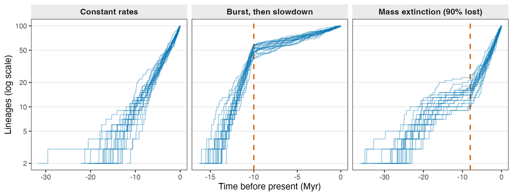

Simulations with TreeSim (R package), 20 trees of 100 tips per panel. Constant: λ 0.3, μ 0.1. Burst: λ 0.8 before 10 Myr ago and 0.08 after, μ 0.04. Mass extinction: λ 0.3, μ 0.1, and 90% of lineages lost 8 Myr ago.

- **Burst, then slowdown:** fast speciation until the new space fills. Could be a diversity dependent slowdown (Rabosky and Lovette 2008).
- **Mass extinction:** species accumulation slows or stops during the event and resumes afterward.
- The LTT plots give hints about past rate changes, but still possible that a combination of processes could produce similar patterns.

## Can we estimate $\lambda(t)$ with a tree?

- One simulated tree with 200 species. We decrease $\lambda$ from 0.6 to 0.15 six million years ago. $\mu = 0.05$ is constant over time.
- We can use `diversitree` in R to fit constant, linear, and step models of speciation and extinction.
- The step model found $\lambda$ changed from 0.57 to 0.145 at 6.0 Myr, and $\mu = 0.07$.

```r
fit_tree <- sim.rateshift.taxa(n = 200, numbsim = 1, lambda = c(0.15, 0.6), mu = c(0.05, 0.05),
                              frac = c(1, 1), times = c(0, 6), complete = FALSE)
```

| Model | Rates | $\Delta \ln L$ | $\Delta$AIC |
| --- | --- | --- | --- |
| constant rates | 2 | −39.5 | 75.1 |
| speciation changes linearly | 3 | −20.4 | 38.7 |
| speciation changes once | 4 | 0.0 | 0.0 |

## Rates that track the environment

$$\lambda(t) = \lambda_0 \, e^{\beta\, \mathrm{env}(t)}$$

$\mathrm{env}(t)$ is a paleotemperature or paleoelevation curve. $\beta = 0$ means constant rates (Condamine, Rolland, and Morlon 2013).

- **Andean bellflowers:** speciation rose with Andean elevation, and extinction fell as the climate cooled. The centropogonids reached 550 species in 5 million years (Lagomarsino et al. 2016).
- **All angiosperms:** Cenozoic rates rose as global temperatures fell (Zuntini et al. 2024).
- **Mountains everywhere:** alpine radiations are young and fast, like Andean *Lupinus* (Hughes and Atchison 2015).

## Rates that track the environment

Possible to fit rates over the tree, and they may align with major environmental or other abiotic changes as well as biotic.

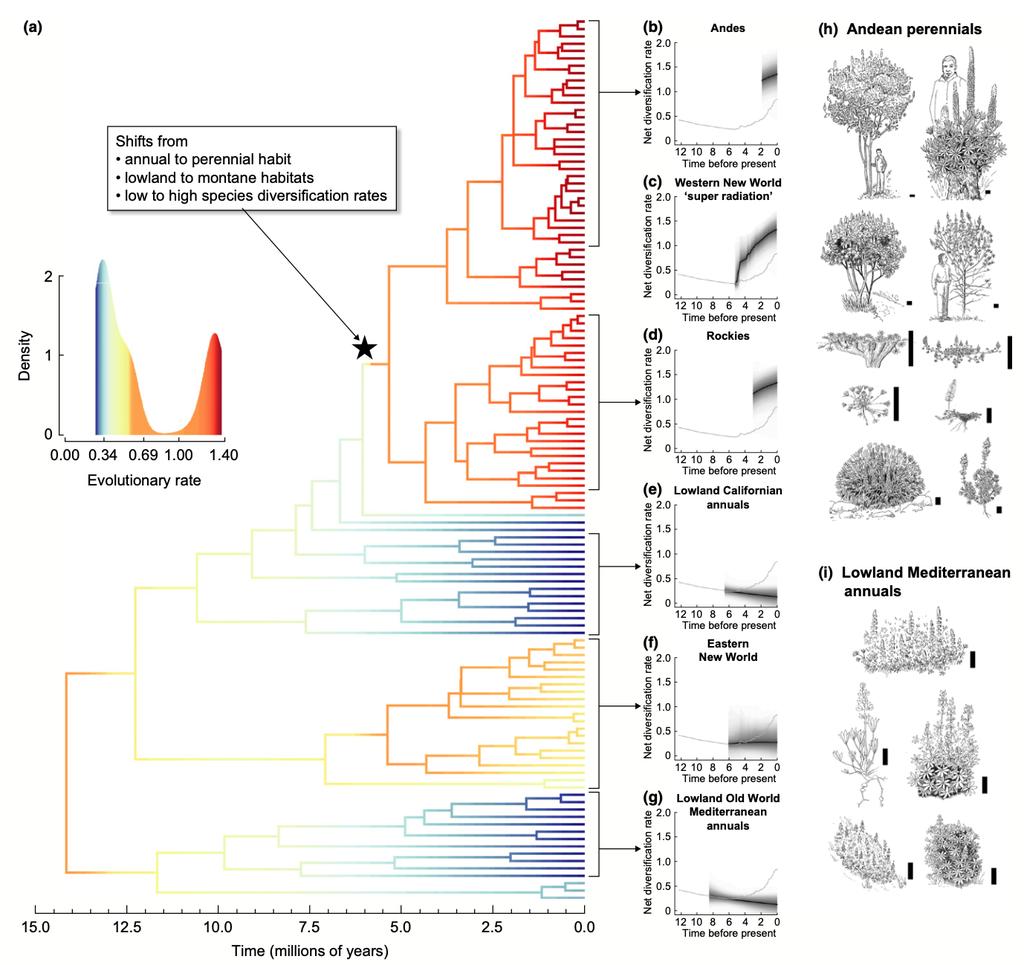

Variable diversification shows recent alpine radiations. Fig. 1 from Hughes and Atchison (2015)

## Rates that track the environment

[figure not shown]

Correlations between diversification rates and paleoclimate. Fig. 3 from Palazzesi et al. (2022)

## Rates that track space

- Rates change through time, but the space organisms occupy changes too. Organisms do not stick to their ancestral area, the can disperse and those area can change too.
- Biogeographic models like DEC explicitly account for these dynamics, modeling how ranges evolve along branches and at speciation events.

# Ancestral areas, vicariance, and dispersal

## Ranges as sets of areas

- The Hawaiian silversword alliance is a rapid radiation with $r=0.56$ species per lineage per Myr (Baldwin and Sanderson 1998).
- Consider four areas: Kauai (K), Oahu (O), Maui Nui (M) and Hawaii (H).
- A range is the set of areas a species occupies - could be a single island or all!
- Four areas give $2^4 = 16$ possible ranges, so range is a discrete trait with 16 states.

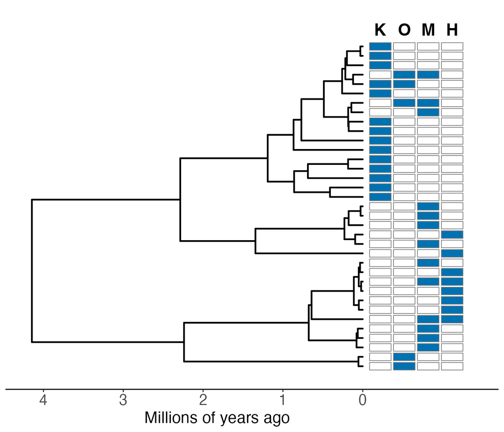

## From Mk to DEC

DEC (dispersal–extinction–cladogenesis) builds on Mk by treating ranges as states (Ree et al. 2005; Ree and Smith 2008). There are some restrictions on how an ancestor’s range is passed to its children.

$$Q = \begin{pmatrix} -d & 0 & d \\ 0 & -d & d \\ e & e & -2e \end{pmatrix}$$

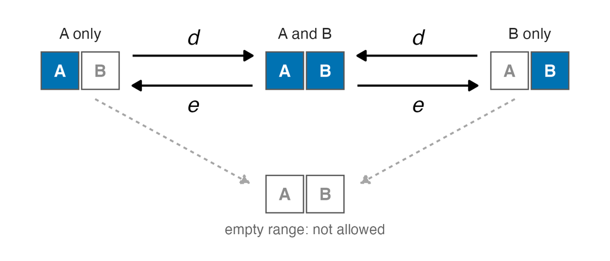

## What happens at a node

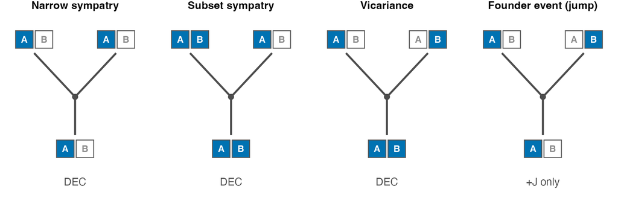

- In DEC, one daughter always gets a single area. The other gets the whole range (subset sympatry) or the rest of it (vicariance).
- +J adds founder events: one daughter jumps to a new area at the moment of speciation (Matzke 2014).

## The same pruning algorithm to get the likelihood with Mk or DNA-based models

$$\begin{aligned}
\text{tip:}\quad & L_k(s) = 1 \text{ if the tip's range is } s, \text{ otherwise } 0 \\[4pt]
\text{along a branch:}\quad & P(v) = e^{Qv}, \text{ exactly as in Mk} \\[4pt]
\text{node:}\quad & L_k(s) = \sum_{x,y} C(s \to x, y) \Big[\sum_{x'} P_{xx'}(v_i)\,L_i(x')\Big]
\Big[\sum_{y'} P_{yy'}(v_j)\,L_j(y')\Big] \\[4pt]
\text{root:}\quad & L = \textstyle\sum_s \pi_s\, L_{\text{root}}(s)
\end{aligned}$$

- DEC adds one extra sum over how the range splits, $C(s \to x, y)$.
- DEC has no $\lambda$ or $\mu$. Range can’t change how fast lineages diversify (yet).

## Silverswords under DEC

DEC is nice because it is relatively simple, but it has some limitation with the silverswords here:

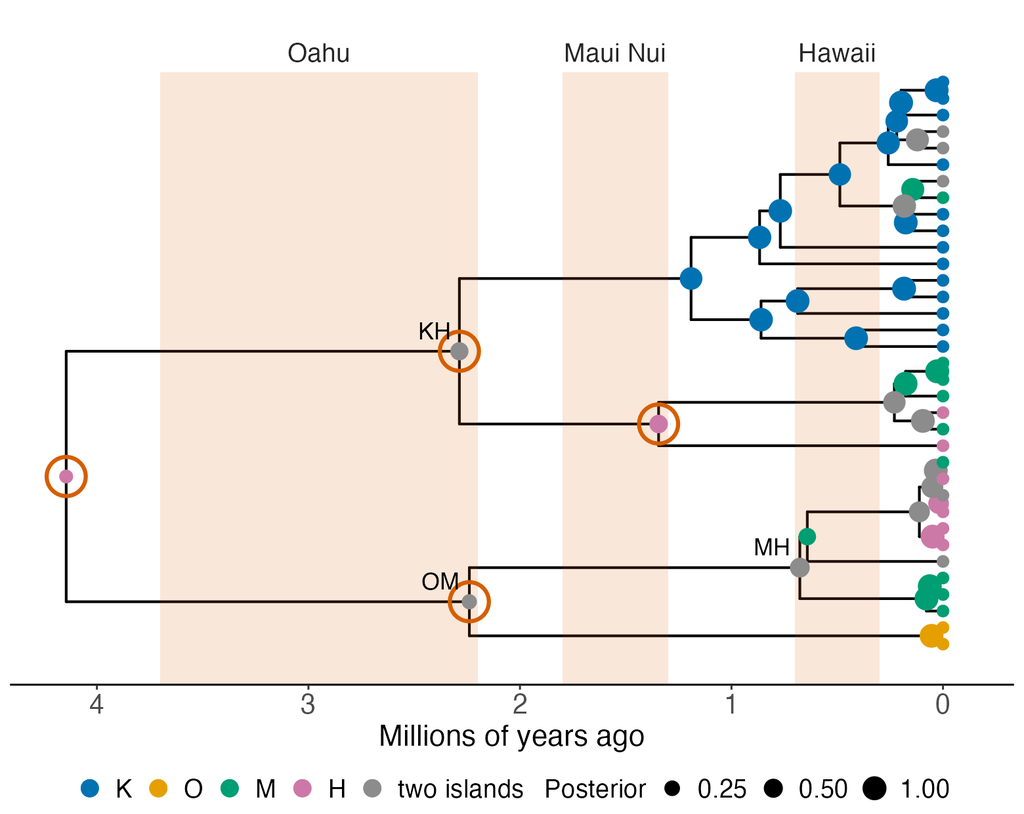

## Areas have ages

Age of the islands are well known: - Oahu emerged 3.7–2.2 million years ago, Maui Nui 1.8–1.3 and Hawaii 0.7–0.3. Kauai is older than the tree. - Multiple transition rate matricies ($Q$) can be specified over discrete time intervals. - Set dispersal into an island to zero until it emerges, and $Q$ changes at each boundary (Landis 2017).

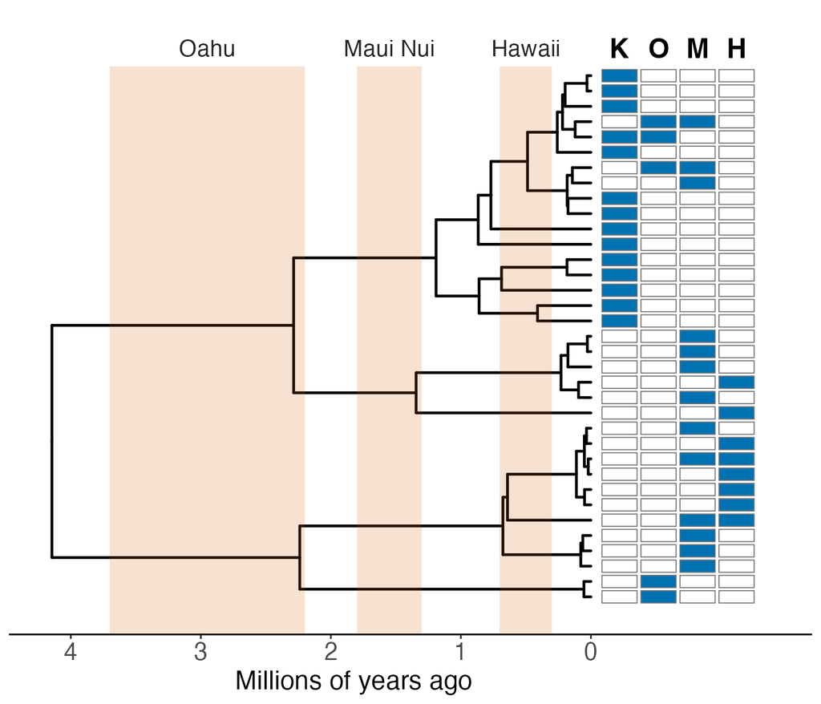

## Silverswords with island ages

- No ancestor sits on an island before it emerged. Deep nodes imply extinction on intermediate steps.
- The Kauai root is assumed.
- Two-island ancestors drop from 10 to 4.
- Island ages can be used here to date a tree with no fossils (Landis 2017).

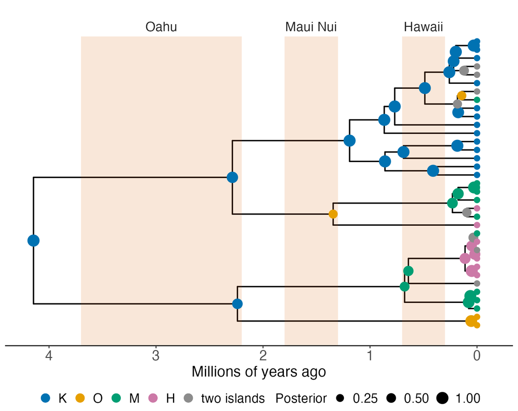

## When geography changes rates: GeoSSE

- DEC takes the tree as given, so range can’t change $\lambda$ or $\mu$.
- GeoSSE (geographic state-dependent speciation and extinction) joins range evolution to birth–death, like BiSSE with three states: A, B and AB (Goldberg, Lancaster, and Ree 2011).
- Extinction from an area is now possible!

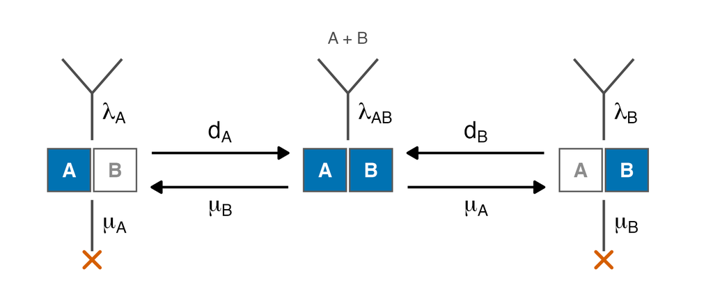

## DEC vs. GeoSSE

|  | **DEC** | **GeoSSE** |
| --- | --- | --- |
| The tree is | fixed by user | generated by the model |
| Range is | a neutral trait | able to change $\lambda$ and $\mu$ |
| Losing the last area | not allowed | extinction |
| Estimates | $d$, $e$, ancestral ranges | $\lambda_A, \lambda_B, \lambda_{AB}$, $\mu_A, \mu_B$, $d_A, d_B$, ancestral ranges |

Both models are implemented in the software language RevBayes as `dnPhyloCTMCClado` and `dnGLHBDSP`, respectively.

## GeoSSE has the criticisms of other SSE models

- A “region effect” can be one fast clade that happens to be there. This is the same false positive concern with BiSSE.

How would you solve this problem of detecting biogeographic effects by chance?

## GeoSSE has the criticisms of other SSE models

- A “region effect” can be one fast clade that happens to be there. This is the same false positive concern with BiSSE.
- GeoHiSSE adds hidden states, so rates can vary for reasons other than region. Its CID-style null lets rates vary, but not with region (Caetano, O’Meara, and Beaulieu 2018).
- Fit both before claiming that a region drives diversification.

## Putting it together: Andean orchids

- Andean orchids are young (the last 20–15 million years), and descended from lowland Amazonian ancestors.
- Orchids, like many other groups we have discussed, diversified due to the Andean uplifts (Pérez-Escobar et al. 2017).
- Area-dependent rates (GeoSSE) explains a regional hotspot in the Northern Andes (the most recent uplift).

## Putting it together: Andean orchids

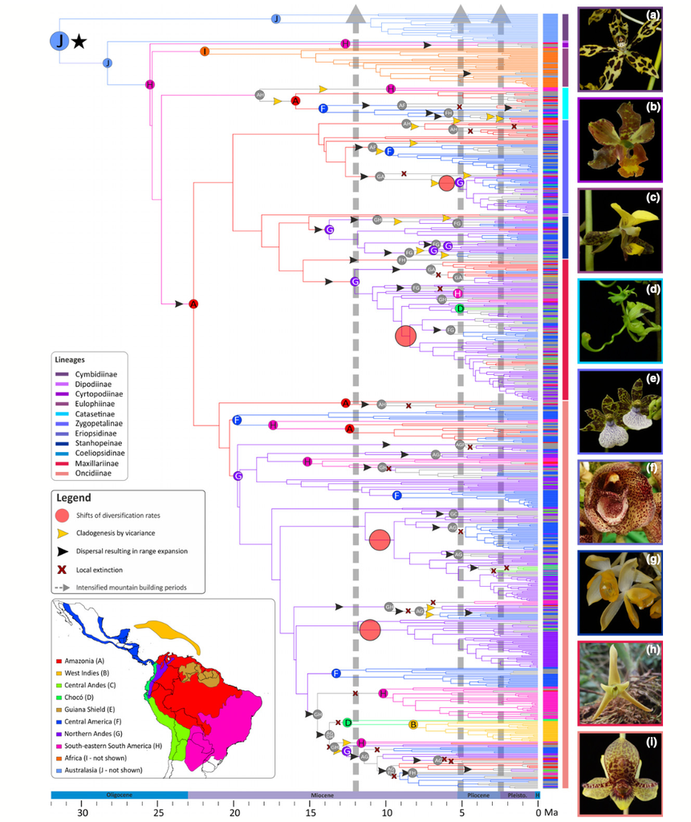

Reconstruction of Cymbidieae orchid diversification. Fig. 1 from Pérez-Escobar et al. (2017)

## Putting it together: Andean orchids

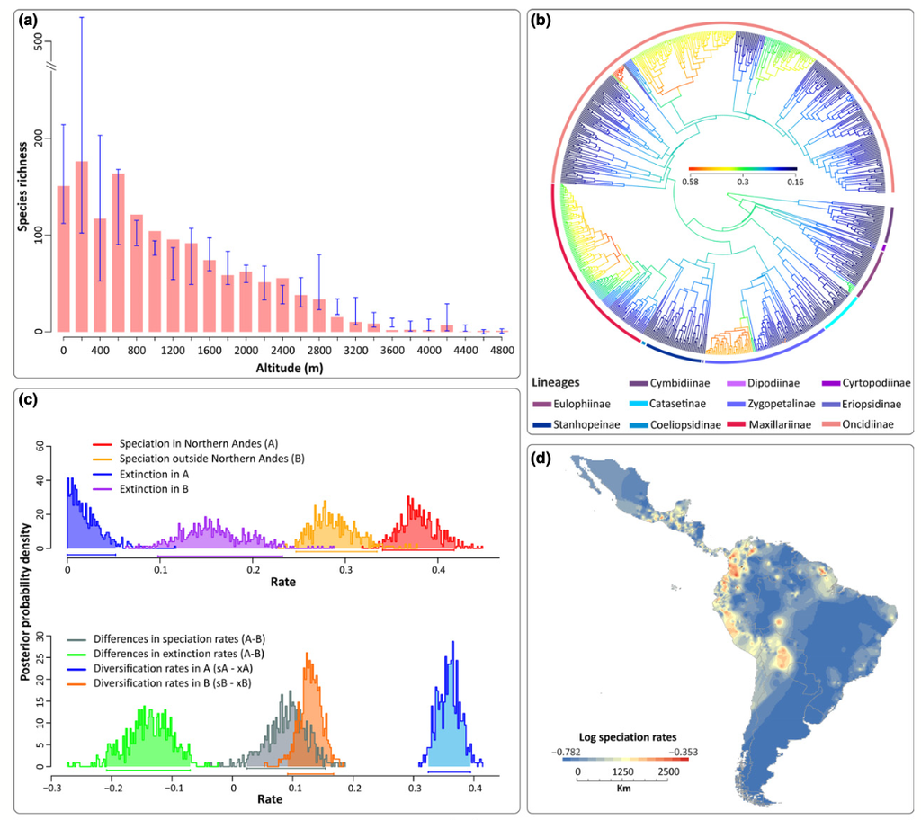

Recovery of higher diversification in the Northern Andes compared to the rest of the range. Fig. 3 from Pérez-Escobar et al. (2017)

# Key takeaways

## Summary

- Plant richness and endemism vary among regions. General expectations for tropics hold true.
- Time, rate and carrying capacity can each make the tropics rich. Plant phylogenies point more to time and carrying capacity.
- But those orchids and legumes were fast!
- It is possible to estimate changing speciation and extinction rates through time, but many changes will not be easy to detect.
- DEC is Mk on ranges plus cladogenesis.
- Epochs can account for timing of areas.
- GeoSSE lets geography change $\lambda$ and $\mu$, and needs hidden-state nulls like any SSE model.

# References

Baldwin, Bruce G., and Michael J. Sanderson. 1998. “Age and Rate of Diversification of the Hawaiian Silversword Alliance (Compositae).” *Proceedings of the National Academy of Sciences* 95 (16): 9402–6. https://doi.org/10.1073/pnas.95.16.9402.

Caetano, Daniel S., Brian C. O’Meara, and Jeremy M. Beaulieu. 2018. “Hidden State Models Improve State-Dependent Diversification Approaches, Including Biogeographical Models.” *Evolution* 72 (11): 2308–24. https://doi.org/10.1111/evo.13602.

Condamine, Fabien L., Jonathan Rolland, and Hélène Morlon. 2013. “Macroevolutionary Perspectives to Environmental Change.” *Ecology Letters* 16 (s1): 72–85. https://doi.org/10.1111/ele.12062.

Goldberg, Emma E., Lesley T. Lancaster, and Richard H. Ree. 2011. “Phylogenetic Inference of Reciprocal Effects Between Geographic Range Evolution and Diversification.” *Systematic Biology* 60 (4): 451–65. https://doi.org/10.1093/sysbio/syr046.

Govaerts, Rafaël, Eimear Nic Lughadha, Nicholas Black, Robert Turner, and Alan Paton. 2021. “The World Checklist of Vascular Plants, a Continuously Updated Resource for Exploring Global Plant Diversity.” *Scientific Data* 8: 215. https://doi.org/10.1038/s41597-021-00997-6.

Hughes, Colin E., and Guy W. Atchison. 2015. “The Ubiquity of Alpine Plant Radiations: From the Andes to the Hengduan Mountains.” *New Phytologist* 207 (2): 275–82. https://doi.org/10.1111/nph.13230.

Jablonski, David, Kaustuv Roy, and James W. Valentine. 2006. “Out of the Tropics: Evolutionary Dynamics of the Latitudinal Diversity Gradient.” *Science* 314 (5796): 102–6. https://doi.org/10.1126/science.1130880.

Kerkhoff, Andrew J., Pamela E. Moriarty, and Michael D. Weiser. 2014. “The Latitudinal Species Richness Gradient in New World Woody Angiosperms Is Consistent with the Tropical Conservatism Hypothesis.” *Proceedings of the National Academy of Sciences* 111 (22): 8125–30. https://doi.org/10.1073/pnas.1308932111.

Lagomarsino, Laura P., Fabien L. Condamine, Alexandre Antonelli, Andreas Mulch, and Charles C. Davis. 2016. “The Abiotic and Biotic Drivers of Rapid Diversification in Andean Bellflowers (Campanulaceae).” *New Phytologist* 210 (4): 1430–42. https://doi.org/10.1111/nph.13920.

Landis, Michael J. 2017. “Biogeographic Dating of Speciation Times Using Paleogeographically Informed Processes.” *Systematic Biology* 66 (2): 128–44. https://doi.org/10.1093/sysbio/syw040.

Matzke, Nicholas J. 2014. “Model Selection in Historical Biogeography Reveals That Founder-Event Speciation Is a Crucial Process in Island Clades.” *Systematic Biology* 63 (6): 951–70. https://doi.org/10.1093/sysbio/syu056.

Mittelbach, Gary G., Douglas W. Schemske, Howard V. Cornell, Andrew P. Allen, Jonathan M. Brown, Mark B. Bush, Susan P. Harrison, et al. 2007. “Evolution and the Latitudinal Diversity Gradient: Speciation, Extinction and Biogeography.” *Ecology Letters* 10 (4): 315–31. https://doi.org/10.1111/j.1461-0248.2007.01020.x.

Morlon, Hélène, Todd L. Parsons, and Joshua B. Plotkin. 2011. “Reconciling Molecular Phylogenies with the Fossil Record.” *Proceedings of the National Academy of Sciences* 108 (39): 16327–32. https://doi.org/10.1073/pnas.1102543108.

Palazzesi, Luis, Oriane Hidalgo, Viviana D Barreda, Félix Forest, and Sebastian Höhna. 2022. “The Rise of Grasslands Is Linked to Atmospheric CO2 Decline in the Late Palaeogene.” *Nature Communications* 13 (1): 293.

Pérez-Escobar, Oscar Alejandro, Guillaume Chomicki, Fabien L. Condamine, Adam P. Karremans, Diego Bogarín, Nicholas J. Matzke, Daniele Silvestro, and Alexandre Antonelli. 2017. “Recent Origin and Rapid Speciation of Neotropical Orchids in the World’s Richest Plant Biodiversity Hotspot.” *New Phytologist* 215 (2): 891–905. https://doi.org/10.1111/nph.14629.

Price, Jonathan P., and David A. Clague. 2002. “How Old Is the Hawaiian Biota? Geology and Phylogeny Suggest Recent Divergence.” *Proceedings of the Royal Society B: Biological Sciences* 269 (1508): 2429–35. https://doi.org/10.1098/rspb.2002.2175.

Rabosky, Daniel L., and Irby J. Lovette. 2008. “Explosive Evolutionary Radiations: Decreasing Speciation or Increasing Extinction Through Time?” *Evolution* 62 (8): 1866–75. https://doi.org/10.1111/j.1558-5646.2008.00409.x.

Ree, Richard H., Brian R. Moore, Campbell O. Webb, and Michael J. Donoghue. 2005. “A Likelihood Framework for Inferring the Evolution of Geographic Range on Phylogenetic Trees.” *Evolution* 59 (11): 2299–2311. https://doi.org/10.1554/05-172.1.

Ree, Richard H., and Stephen A. Smith. 2008. “Maximum Likelihood Inference of Geographic Range Evolution by Dispersal, Local Extinction, and Cladogenesis.” *Systematic Biology* 57 (1): 4–14. https://doi.org/10.1080/10635150701883881.

Stadler, Tanja. 2011. “Mammalian Phylogeny Reveals Recent Diversification Rate Shifts.” *Proceedings of the National Academy of Sciences* 108 (15): 6187–92. https://doi.org/10.1073/pnas.1016876108.

Tietje, Melanie, Alexandre Antonelli, William J. Baker, Rafaël Govaerts, Stephen A. Smith, and Wolf L. Eiserhardt. 2022. “Global Variation in Diversification Rate and Species Richness Are Unlinked in Plants.” *Proceedings of the National Academy of Sciences* 119 (27): e2120662119. https://doi.org/10.1073/pnas.2120662119.

Wiens, John J., and Michael J. Donoghue. 2004. “Historical Biogeography, Ecology and Species Richness.” *Trends in Ecology & Evolution* 19 (12): 639–44. https://doi.org/10.1016/j.tree.2004.09.011.

Zuntini, Alexandre R., Tom Carruthers, Olivier Maurin, et al. 2024. “Phylogenomics and the Rise of the Angiosperms.” *Nature* 629 (8013): 843–50. https://doi.org/10.1038/s41586-024-07324-0.